# hichipper QC report

2017-12-29

hichipper, version 0.7.1.

## Summary Tables

|  | K562_Rep1 | K562_Rep3 | K562_Rep2 |
| --- | --- | --- | --- |
| Total PETs | 213165389 | 178162951 | 155907950 |
| % Reads in Anchors | 56.47 | 57.56 | 71.59 |
| % HQ Unique Mapped | 106.67 | 100.20 | 106.81 |
| % Long Range Interaction | 21.55 | 18.17 | 22.78 |
| % in Loops | 1.65 | 1.53 | 2.27 |

The first summary table notes how many PETs are in each sample and what fraction were mapped with high-quality. First, the “% Reads in Anchors” takes all unique, mappable pairs (whether they are valid, dangling, self-circle, etc. doesn’t matter) and determines what fraction have both overlapping with anchor loci. Note, this numer should give an indication of the ChIP quality, but it may be sensitive to how peaks are determined with padding, etc. While the “% HQ Unique Mapped” reads should be self explanatory, the “% Long Range Interaction” value represents the number of intrachromosomal reads longer than the minimum length (default 5Kb) specified by the user and is a good approximation for the efficacy of the in situ ligation. Finally, the “% in Loops” is the fraction of total reads that are in loops, defined by high-quality, mapped intrachromosomal, anchor-mapped, between min and max lengths (default 5Kb and 2Mb). If the proportion of loops reads is low but the proportion of long range interactions is high, this suggests that the ChIP efficiency is relatively low.

|  | K562_Rep1 | K562_Rep3 | K562_Rep2 |
| --- | --- | --- | --- |
| Intrachromasomal PETs | 73198912 | 52708198 | 55118481 |
| % Reads < 5Kb | 25.07 | 27.85 | 25.05 |
| % Reads in 5KB-2Mb | 62.76 | 61.41 | 64.44 |
| % Reads > 2Mb | 12.17 | 10.74 | 10.51 |

The second summary table shows the total number of intrachromosomal pets and the distance that they span binned by the max and min user defined distances. Only reads in the middle are used when making loops but all are used for anchor calling. If the very long interactions are disproportionately abundant, the proximity ligation step may not have been effective. In contrast, if the short range interactions are disproportionately abundant, issues with the in situ ligation likely occurred in the experiment.

## Loop Width Distribution Histogram

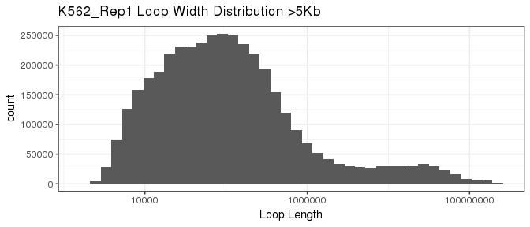

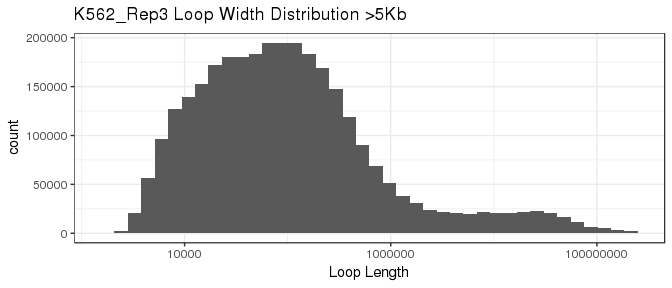

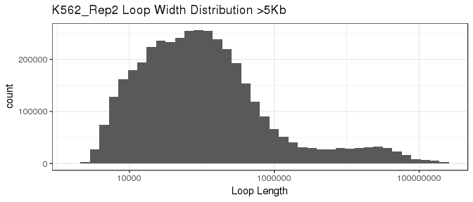

Above is a histogram of the loop widths greater than the minimum distance supplied in the parameters. Note that the loops smaller than the minimum distance have been filtered to make the histogram more interpretable (refer to the table above to see the proportion of very loops below the minimum distance, which are likely self-ligations).

## Raw Read Stats

|  | K562_Rep1 | K562_Rep3 | K562_Rep2 |
| --- | --- | --- | --- |
| Total_PETs | 213,165,389 | 178,162,951 | 155,907,950 |
| Mapped_unique_quality | 227,379,220 | 178,511,506 | 166,531,145 |
| Mapped_unique_quality_valid | 84,853,173 | 60,184,588 | 63,563,804 |
| Valid_Intra | 73,198,912 | 52,708,198 | 55,118,481 |
| Valid_Intra_<5Kb | 18,352,064 | 14,680,263 | 13,808,130 |
| Valid_Intra_5Kb-2Mb | 45,942,066 | 32,366,438 | 35,517,487 |
| Valid_Intra_>2Mb | 8,904,782 | 5,661,497 | 5,792,864 |
| Valid_Intra_anchor_5Kb-2Mb | 3,506,603 | 2,720,245 | 3,542,961 |
| HQ_Reads_In_Anchors | 120,370,198 | 102,544,038 | 111,609,121 |

## Proportional Read Stats

|  | K562_Rep1 | K562_Rep3 | K562_Rep2 |
| --- | --- | --- | --- |
| Total_PETs | 100.00 | 100.00 | 100.00 |
| Mapped_unique_quality | 106.67 | 100.20 | 106.81 |
| Mapped_unique_quality_valid | 39.81 | 33.78 | 40.77 |
| Valid_Intra | 34.34 | 29.58 | 35.35 |
| Valid_Intra_<5Kb | 8.61 | 8.24 | 8.86 |
| Valid_Intra_5Kb-2Mb | 21.55 | 18.17 | 22.78 |
| Valid_Intra_>2Mb | 4.18 | 3.18 | 3.72 |
| Valid_Intra_anchor_5Kb-2Mb | 1.65 | 1.53 | 2.27 |
| Long_Range_Interactions | 21.55 | 18.17 | 22.78 |

## Number of Anchor Peaks

| sample | npeaks |
| --- | --- |
| K562_Rep1 | 84598 |
| K562_Rep3 | 84598 |
| K562_Rep2 | 84598 |

The number of anchor peaks used in each sample. In lowly sequenced samples, these numbers may be low and be responsible for the lack of PETs mapping into loops.